# Assignment Instructions: Module 8 - DEA

shiva gadila

2023-10-29

```r
library(Benchmarking)
library(lpSolveAPI)
library( ucminf)
library(quadprog)
```

```r
Data<- data.frame(
  DMU= c("Facility 1","Facility 2","Facility 3","Facility 4","Facility 5","Facility 6 "),
  staff_hours_per_day = c(100,300,320,500,350,340),
  suppliers_per_day=c(0.3,0.6,1.2,2,1.4,0.7),
  Reimbursed_patient_per_day= c(15000,15000,40000,28000,20000,14000),
  privately_paid_patient_days= c(3500,20000,11000,42000,25000,15000)
)
```

```r
library(knitr)
kable(Data, format = "pandoc", caption = "Hope Valley Health Care Association")
```

Hope Valley Health Care Association

| DMU | staff_hours_per_day | suppliers_per_day | Reimbursed_patient_per_day | privately_paid_patient_days |
| --- | --- | --- | --- | --- |
| Facility 1 | 100 | 0.3 | 15000 | 3500 |
| Facility 2 | 300 | 0.6 | 15000 | 20000 |
| Facility 3 | 320 | 1.2 | 40000 | 11000 |
| Facility 4 | 500 | 2.0 | 28000 | 42000 |
| Facility 5 | 350 | 1.4 | 20000 | 25000 |
| Facility 6 | 340 | 0.7 | 14000 | 15000 |

```r
x<- matrix(c(100,300,320,500,350,340,0.3,0.6,1.2,2,1.4,0.7),ncol = 2)
y<- matrix(c(15000,15000,40000,28000,20000,14000,3500,20000,11000,42000,25000,15000),ncol=2)
colnames(y)<-c("Reimbursed_patient_per_day","privately_paid_patientdays")
colnames(x)<-c("staff_hours","suppliers_per_day")
```

#1. Formulate and perform DEA analysis under all DEA assumptions of FDH, CRS, VRS, IRS, DRS, and FRH.

```r
#DEA analysis using the CRS(constant return to scale).
CRS_Analysis<- dea(x,y,RTS = "crs")
#efficiency results derived from the DEA analysis under the CRS assumption.
CRS_efficiency<- data.frame(CRS_Analysis$eff)
CRS_efficiency
```

```
##   CRS_Analysis.eff
## 1        1.0000000
## 2        1.0000000
## 3        0.8793468
## 4        1.0000000
## 5        0.8941998
## 6        0.7047619
```

```r
#DEA analysis using the FDH(Free Disposability Hull).
FDH_Analysis<- dea(x,y, RTS = "FDH")
#efficiency results derived from the DEA analysis under the FDH assumption.
FDH_efficiency<- data.frame(FDH_Analysis$eff)
FDH_efficiency
```

```
##   FDH_Analysis.eff
## 1        1.0000000
## 2        1.0000000
## 3        1.0000000
## 4        1.0000000
## 5        1.0000000
## 6        0.8823529
```

```r
#DEA analysis using the VRS(Varying return to scale).
VRS_Analysis<- dea(x,y,RTS = "VRS")
#efficiency results derived from the DEA analysis under the VRS assumption.
VRS_efficiency<- data.frame(VRS_Analysis$eff)
VRS_efficiency
```

```
##   VRS_Analysis.eff
## 1        1.0000000
## 2        1.0000000
## 3        1.0000000
## 4        1.0000000
## 5        0.9239332
## 6        0.7272727
```

```r
#DEA analysis using the IRS(increasing return to scale).
IRS_Analysis<- dea(x,y,RTS = "IRS")
#efficiency results derived from the DEA analysis under the IRS assumption
IRS_efficiency<- data.frame(IRS_Analysis$eff)
IRS_efficiency
```

```
##   IRS_Analysis.eff
## 1        1.0000000
## 2        1.0000000
## 3        0.8793468
## 4        1.0000000
## 5        0.9239332
## 6        0.7272727
```

```r
#DEA analysis using the DRS(Decrease return to scale).
DRS_Analysis<- dea(x,y, RTS = "DRS")
#efficiency results derived from the DEA analysis under the DRS assumption
DRS_efficiency<- data.frame(DRS_Analysis$eff)
DRS_efficiency
```

```
##   DRS_Analysis.eff
## 1        1.0000000
## 2        1.0000000
## 3        1.0000000
## 4        1.0000000
## 5        0.8941998
## 6        0.7047619
```

```r
#DEA analysis using the FRH(Free Replicability Hull).
FRH_Analysis<- dea(x,y, RTS = "add")
#efficiency results derived from the DEA analysis under the DRS assumption
FRH_efficiency<- data.frame(FRH_Analysis$eff)
FRH_efficiency
```

```
##   FRH_Analysis.eff
## 1        1.0000000
## 2        1.0000000
## 3        1.0000000
## 4        1.0000000
## 5        1.0000000
## 6        0.8823529
```

```r
# Combine all efficiency scores into a data frame
efficiency_data <- data.frame(
  DMU = Data$DMU,
  CRS_Efficiency = CRS_efficiency$CRS_Analysis.eff,
  FDH_Efficiency = FDH_efficiency$FDH_Analysis.eff,
  VRS_Efficiency = VRS_efficiency$VRS_Analysis.eff,
  IRS_Efficiency = IRS_efficiency$IRS_Analysis.eff,
  DRS_Efficiency = DRS_efficiency$DRS_Analysis.eff,
  FRH_Efficiency = FRH_efficiency$FRH_Analysis.eff
)

# Print the combined data frame
efficiency_data
```

```
##           DMU CRS_Efficiency FDH_Efficiency VRS_Efficiency IRS_Efficiency
## 1  Facility 1      1.0000000      1.0000000      1.0000000      1.0000000
## 2  Facility 2      1.0000000      1.0000000      1.0000000      1.0000000
## 3  Facility 3      0.8793468      1.0000000      1.0000000      0.8793468
## 4  Facility 4      1.0000000      1.0000000      1.0000000      1.0000000
## 5  Facility 5      0.8941998      1.0000000      0.9239332      0.9239332
## 6 Facility 6       0.7047619      0.8823529      0.7272727      0.7272727
##   DRS_Efficiency FRH_Efficiency
## 1      1.0000000      1.0000000
## 2      1.0000000      1.0000000
## 3      1.0000000      1.0000000
## 4      1.0000000      1.0000000
## 5      0.8941998      1.0000000
## 6      0.7047619      0.8823529
```

#I utilized Data Envelopment Analysis to evaluate the efficiency of multiple Decision-Making Units while considering different assumptions. We performed DEA analysis under six distinct scenarios: Constant Return to Scale , Free Disposability Hull, Varying Return to Scale, Increasing Return to Scale, Decreasing Return to Scale, and Free Replicability Hull. The efficiency scores for each DMU under these assumptions were stored in separate data frames. To aid comparison, we consolidated these efficiency scores into a single data frame, “efficiency_data,” with one row per DMU and columns for each assumption’s efficiency scores.

#2. Determine the Peers and Lambdas under each of the above assumptions

```r
#peers for the CRS.
CRS_Peers<- peers(CRS_Analysis)
CRS_Peers
```

```
##      peer1 peer2
## [1,]     1    NA
## [2,]     2    NA
## [3,]     1     4
## [4,]     4    NA
## [5,]     1     4
## [6,]     1     2
```

```r
#Determining the weights using the lambda function for the peer values for the CRS
CRS_lambda<- lambda(CRS_Analysis)
CRS_lambda
```

```
##             L1        L2         L4
## [1,] 1.0000000 0.0000000 0.00000000
## [2,] 0.0000000 1.0000000 0.00000000
## [3,] 2.5789474 0.0000000 0.04699248
## [4,] 0.0000000 0.0000000 1.00000000
## [5,] 0.2631579 0.0000000 0.57330827
## [6,] 0.2222222 0.7111111 0.00000000
```

```r
#Peers for the FDH.
FDH_Peers<- peers(FDH_Analysis)
FDH_Peers
```

```
##      peer1
## [1,]     1
## [2,]     2
## [3,]     3
## [4,]     4
## [5,]     5
## [6,]     2
```

```r
#Determining the weights using the lambda function for the peer values for the FDH.
FDH_lambda<- lambda(FDH_Analysis)
FDH_lambda
```

```
##      L1 L2 L3 L4 L5
## [1,]  1  0  0  0  0
## [2,]  0  1  0  0  0
## [3,]  0  0  1  0  0
## [4,]  0  0  0  1  0
## [5,]  0  0  0  0  1
## [6,]  0  1  0  0  0
```

```r
#Peers for the VRS.
VRS_Peers<- peers(VRS_Analysis)
VRS_Peers
```

```
##      peer1 peer2
## [1,]     1    NA
## [2,]     2    NA
## [3,]     3    NA
## [4,]     4    NA
## [5,]     1     4
## [6,]     1     2
```

```r
#Determining the weights using the lambda function for the peer values for the VRS.
VRS_lambda<- lambda(VRS_Analysis)
VRS_lambda
```

```
##             L1        L2 L3        L4
## [1,] 1.0000000 0.0000000  0 0.0000000
## [2,] 0.0000000 1.0000000  0 0.0000000
## [3,] 0.0000000 0.0000000  1 0.0000000
## [4,] 0.0000000 0.0000000  0 1.0000000
## [5,] 0.4415584 0.0000000  0 0.5584416
## [6,] 0.3030303 0.6969697  0 0.0000000
```

```r
#Peers for the IRS.
IRS_Peers<- peers(IRS_Analysis)
IRS_Peers
```

```
##      peer1 peer2
## [1,]     1    NA
## [2,]     2    NA
## [3,]     1     4
## [4,]     4    NA
## [5,]     1     4
## [6,]     1     2
```

```r
#Determining the weights using the lambda function for the peer values for the IRS.
IRS_lambda<- lambda(IRS_Analysis)
IRS_lambda
```

```
##             L1        L2         L4
## [1,] 1.0000000 0.0000000 0.00000000
## [2,] 0.0000000 1.0000000 0.00000000
## [3,] 2.5789474 0.0000000 0.04699248
## [4,] 0.0000000 0.0000000 1.00000000
## [5,] 0.4415584 0.0000000 0.55844156
## [6,] 0.3030303 0.6969697 0.00000000
```

```r
#Peers for the DRS.
DRS_Peers<- peers(DRS_Analysis)
DRS_Peers
```

```
##      peer1 peer2
## [1,]     1    NA
## [2,]     2    NA
## [3,]     3    NA
## [4,]     4    NA
## [5,]     1     4
## [6,]     1     2
```

```r
#Determining the weights using the lambda function for the peer values for the DRS.
DRS_lambda<- lambda(DRS_Analysis)
DRS_lambda
```

```
##             L1        L2 L3        L4
## [1,] 1.0000000 0.0000000  0 0.0000000
## [2,] 0.0000000 1.0000000  0 0.0000000
## [3,] 0.0000000 0.0000000  1 0.0000000
## [4,] 0.0000000 0.0000000  0 1.0000000
## [5,] 0.2631579 0.0000000  0 0.5733083
## [6,] 0.2222222 0.7111111  0 0.0000000
```

```r
#Peers for the FRH.
FRH_Peers<- peers(FRH_Analysis)
FRH_Peers
```

```
##      peer1
## [1,]     1
## [2,]     2
## [3,]     3
## [4,]     4
## [5,]     5
## [6,]     2
```

```r
#Determining the weights using the lambda function for the peer values for the FRH.
FRH_lambda<- lambda(FRH_Analysis)
FRH_lambda
```

```
##      L1 L2 L3 L4 L5
## [1,]  1  0  0  0  0
## [2,]  0  1  0  0  0
## [3,]  0  0  1  0  0
## [4,]  0  0  0  1  0
## [5,]  0  0  0  0  1
## [6,]  0  1  0  0  0
```

#I identify peers and calculate Lambdas for various assumptions. Think of peers as similar entities that help us gauge how efficiently a Decision-Making Unit operates. Under different DEA assumptions like constant returns to scale, varying returns to scale, and more, we pinpoint these peers and understand their influence on the efficiency of each DMU. The Lambdas act like weights, showing us the significance of each peer’s role in assessing the target DMU’s efficiency. In simpler terms, we’re finding out which companies or units are like our focal one and how much these similar entities matter when measuring efficiency.

#QUESTION 3 Summarize your results in a tabular format

```r
#Summarizing the results in a tabular format.
CRS_results<- data.frame(CRS_efficiency,CRS_Peers,CRS_lambda)
FDH_results<- data.frame(FDH_efficiency,FDH_Peers,FDH_lambda)
VRS_results<- data.frame(VRS_efficiency, VRS_Peers, VRS_lambda)
IRS_results<- data.frame(IRS_efficiency,IRS_Peers, IRS_lambda)
DRS_results<- data.frame(DRS_efficiency, DRS_Peers,DRS_lambda)
FRH_results<- data.frame(FRH_efficiency,FRH_Peers, FRH_lambda)
```

```r
#Result for Constant return to scale
CRS_results
```

```
##   CRS_Analysis.eff peer1 peer2        L1        L2         L4
## 1        1.0000000     1    NA 1.0000000 0.0000000 0.00000000
## 2        1.0000000     2    NA 0.0000000 1.0000000 0.00000000
## 3        0.8793468     1     4 2.5789474 0.0000000 0.04699248
## 4        1.0000000     4    NA 0.0000000 0.0000000 1.00000000
## 5        0.8941998     1     4 0.2631579 0.0000000 0.57330827
## 6        0.7047619     1     2 0.2222222 0.7111111 0.00000000
```

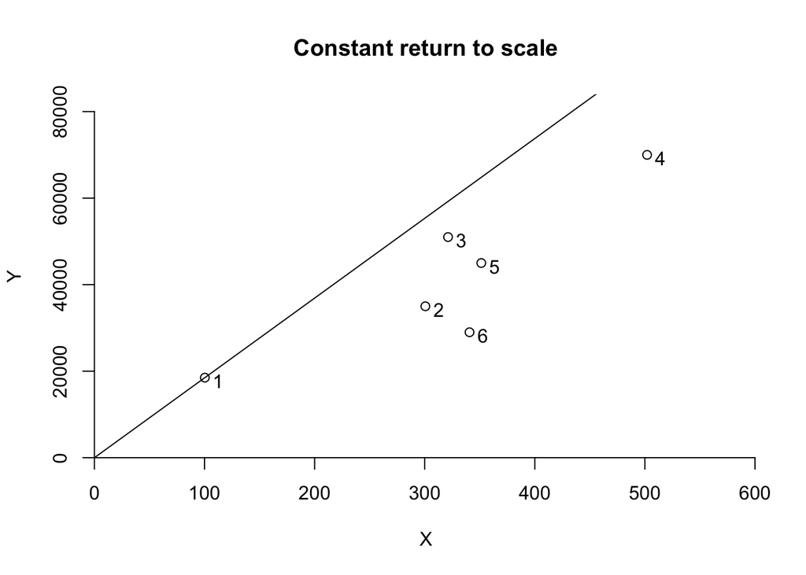

```r
#Plotting the results for Constant return to scale graph.
dea.plot(x,y,RTS="crs",ORIENTATION="in-out",txt=TRUE,main=" Constant return to scale " )
```

```r
#results for Free Disposability Hull
FDH_results
```

```
##   FDH_Analysis.eff peer1 L1 L2 L3 L4 L5
## 1        1.0000000     1  1  0  0  0  0
## 2        1.0000000     2  0  1  0  0  0
## 3        1.0000000     3  0  0  1  0  0
## 4        1.0000000     4  0  0  0  1  0
## 5        1.0000000     5  0  0  0  0  1
## 6        0.8823529     2  0  1  0  0  0
```

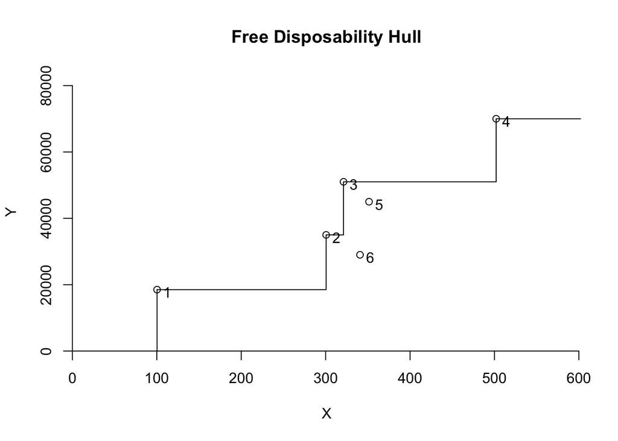

```r
#Plotting the results for Free Disposability Hull graph.
dea.plot(x,y,RTS="fdh",ORIENTATION="in-out",txt=TRUE,main="Free Disposability Hull" )
```

```r
#results for Varying Return to scale
VRS_results
```

```
##   VRS_Analysis.eff peer1 peer2        L1        L2 L3        L4
## 1        1.0000000     1    NA 1.0000000 0.0000000  0 0.0000000
## 2        1.0000000     2    NA 0.0000000 1.0000000  0 0.0000000
## 3        1.0000000     3    NA 0.0000000 0.0000000  1 0.0000000
## 4        1.0000000     4    NA 0.0000000 0.0000000  0 1.0000000
## 5        0.9239332     1     4 0.4415584 0.0000000  0 0.5584416
## 6        0.7272727     1     2 0.3030303 0.6969697  0 0.0000000
```

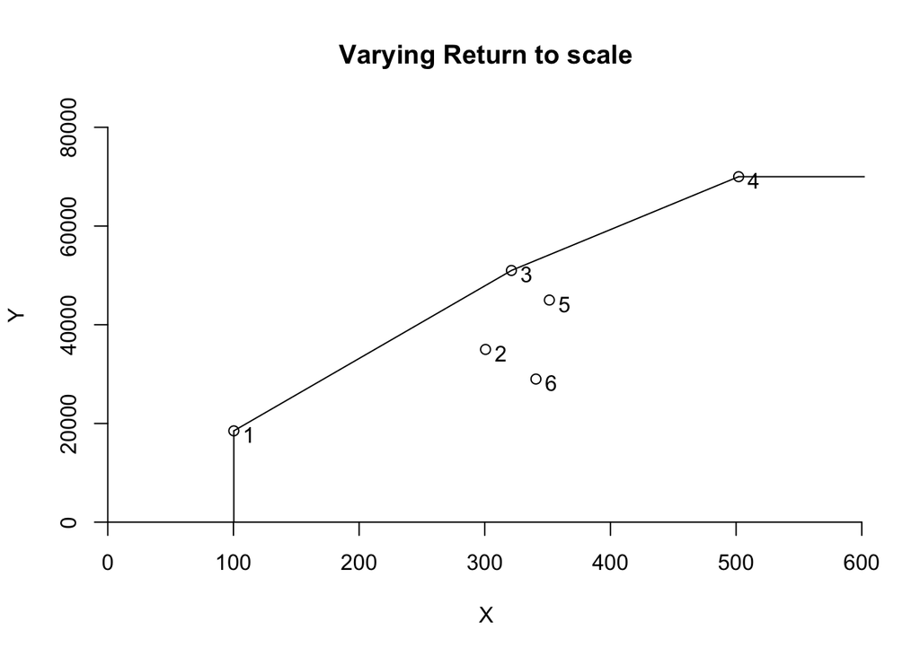

```r
#Plotting the results for Varying Return to scale graph.
dea.plot(x,y,RTS="vrs",ORIENTATION="in-out",txt=TRUE,main="Varying Return to scale" )
```

```r
#results for Decrease in Return to scale
DRS_results
```

```
##   DRS_Analysis.eff peer1 peer2        L1        L2 L3        L4
## 1        1.0000000     1    NA 1.0000000 0.0000000  0 0.0000000
## 2        1.0000000     2    NA 0.0000000 1.0000000  0 0.0000000
## 3        1.0000000     3    NA 0.0000000 0.0000000  1 0.0000000
## 4        1.0000000     4    NA 0.0000000 0.0000000  0 1.0000000
## 5        0.8941998     1     4 0.2631579 0.0000000  0 0.5733083
## 6        0.7047619     1     2 0.2222222 0.7111111  0 0.0000000
```